# Real_data_experiments

# Data sets

All three data sets come from the UCI Repository and are widely known in the ML community. For more details we advise to read the documentation under `?raisin` for raisin dataset. These data sets don’t contain any missing, or categorical values, so only preprocessing needed is the removal of co-linear features, which will be detected via Pearson’s Correlation.

```r
data('raisin')
data('occupancy')
data('banknote')
knitr::kable(head(raisin))
```

| Area | MajorAxisLength | MinorAxisLength | Eccentricity | ConvexArea | Extent | Perimeter | Class |
| --- | --- | --- | --- | --- | --- | --- | --- |
| 87524 | 442.2460 | 253.2912 | 0.8197384 | 90546 | 0.7586506 | 1184.040 | 1 |
| 75166 | 406.6907 | 243.0324 | 0.8018052 | 78789 | 0.6841296 | 1121.786 | 1 |
| 90856 | 442.2670 | 266.3283 | 0.7983536 | 93717 | 0.6376128 | 1208.575 | 1 |
| 45928 | 286.5406 | 208.7600 | 0.6849892 | 47336 | 0.6995994 | 844.162 | 1 |
| 79408 | 352.1908 | 290.8275 | 0.5640113 | 81463 | 0.7927719 | 1073.251 | 1 |
| 49242 | 318.1254 | 200.1221 | 0.7773513 | 51368 | 0.6584564 | 881.836 | 1 |

```r
knitr::kable(head(occupancy))
```

| Temperature | Humidity | Light | CO2 | HumidityRatio | Occupancy |
| --- | --- | --- | --- | --- | --- |
| 23.18 | 27.2720 | 426.0 | 721.25 | 0.0047930 | 1 |
| 23.15 | 27.2675 | 429.5 | 714.00 | 0.0047834 | 1 |
| 23.15 | 27.2450 | 426.0 | 713.50 | 0.0047795 | 1 |
| 23.15 | 27.2000 | 426.0 | 708.25 | 0.0047715 | 1 |
| 23.10 | 27.2000 | 426.0 | 704.50 | 0.0047570 | 1 |
| 23.10 | 27.2000 | 419.0 | 701.00 | 0.0047570 | 1 |

```r
knitr::kable(head(banknote))
```

| X1 | X2 | X3 | X4 | y |
| --- | --- | --- | --- | --- |
| 3.62160 | 8.6661 | -2.8073 | -0.44699 | 0 |
| 4.54590 | 8.1674 | -2.4586 | -1.46210 | 0 |
| 3.86600 | -2.6383 | 1.9242 | 0.10645 | 0 |
| 3.45660 | 9.5228 | -4.0112 | -3.59440 | 0 |
| 0.32924 | -4.4552 | 4.5718 | -0.98880 | 0 |
| 4.36840 | 9.6718 | -3.9606 | -3.16250 | 0 |

## Removing co-linear variables

To ensure obtaining the high quality results we decide to remove co-linear variables, which are the variables having high Pearson’s correlation value (over 0.7).

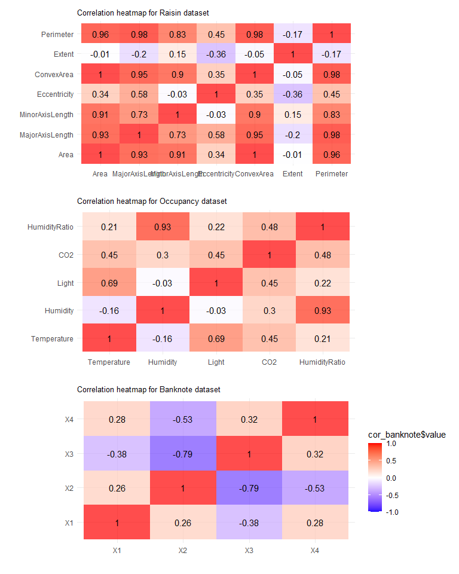

```r
cor_raisin    <- melt(round(cor(select(raisin, Area, MajorAxisLength,
                                       MinorAxisLength, Eccentricity,
                                       ConvexArea, Extent, Perimeter)), 2))
cor_occupancy <- melt(round(cor(select(occupancy, Temperature, Humidity,
                                       Light, CO2, HumidityRatio)), 2))
cor_banknote  <- melt(round(cor(select(banknote, X1, X2, X3, X4)), 2))

plot_heatmaps(cor_raisin, cor_occupancy, cor_banknote)
```

As we can see, Raisin dataset has the abundance of highly correlated features, and we delete all of them. Finally we end up with the data sets described by 3 or 4 features.

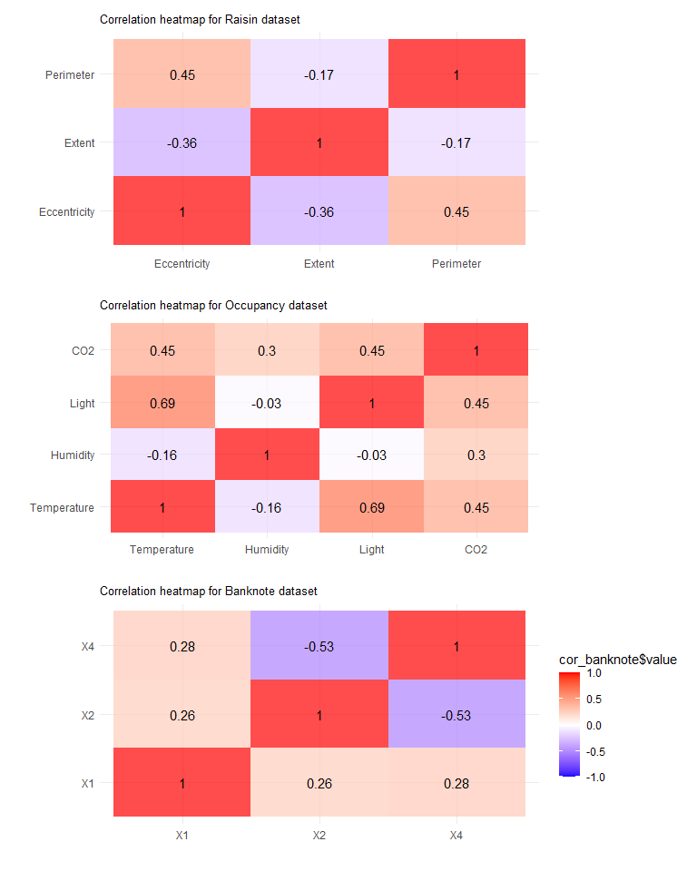

```r
raisin    <- raisin[, -c(1, 2, 3, 5)]
occupancy <- occupancy[, -5]
banknote  <- banknote[, -3]

cor_raisin    <- melt(round(cor(select(raisin, Eccentricity,
                                       Extent, Perimeter)), 2))
cor_occupancy <- melt(round(cor(select(occupancy, Temperature, Humidity,
                                       Light, CO2)), 2))
cor_banknote  <- melt(round(cor(select(banknote, X1, X2, X4)), 2))

plot_heatmaps(cor_raisin, cor_occupancy, cor_banknote)
```

## Train test split

We prepare a train test split from our function which is a wrapper for the split function from `SplitTools`. Additionally we limit the number of observations for the occupancy data set to 2000, as training on all observations is computationally costly.

```r
occupancy       <- occupancy[1:2000, ]
raisin_split    <- train_test_split(raisin, p = c(0.8, 0.2))
occupancy_split <- train_test_split(occupancy, p = c(0.8, 0.2))
banknote_split  <- train_test_split(banknote, p = c(0.8, 0.2))
```

# Experiments

## Singular run

During the first experiment we conduct a singular run of every model and compare the outcomes in form of the table.

### Raisin

```r
train <- raisin_split$train
test  <- raisin_split$test

comp_raisin <- compare_models(train, test, interactions = data.frame(a = c('Perimeter'), b = c('Extent')))
knitr::kable(comp_raisin)
```

| model_names | accuracy | recall | precision | f1 |
| --- | --- | --- | --- | --- |
| our_irls | 0.8555556 | 0.8888889 | 0.8333333 | 0.8602151 |
| our_irls_int | 0.8444444 | 0.8666667 | 0.8297872 | 0.8478261 |
| msme_irls | 0.8555556 | 0.8888889 | 0.8333333 | 0.8602151 |
| LDA | 0.5736111 | 0.6805556 | 0.5606407 | 0.6148055 |
| QDA | 0.5000000 | 0.6666667 | 0.5000000 | 0.5714286 |
| KNN | 0.5000000 | 1.0000000 | 0.5000000 | 0.6666667 |

### Occupancy

```r
train <- occupancy_split$train
test  <- occupancy_split$test

comp_occupancy <- compare_models(train, test, interactions = data.frame(a = c('Light'), b = c('Temperature')))
knitr::kable(comp_occupancy)
```

| model_names | accuracy | recall | precision | f1 |
| --- | --- | --- | --- | --- |
| our_irls | 0.9675000 | 0.9819820 | 0.9083333 | 0.9437229 |
| our_irls_int | 0.9675000 | 0.9819820 | 0.9083333 | 0.9437229 |
| msme_irls | 0.9675000 | 0.9819820 | 0.9083333 | 0.9437229 |
| LDA | 0.5625000 | 0.7500000 | 0.3611714 | 0.4875549 |
| QDA | 0.4258333 | 0.6666667 | 0.2775000 | 0.3918800 |
| KNN | 0.2775000 | 1.0000000 | 0.2775000 | 0.4344423 |

### Banknote

```r
train <- banknote_split$train
test  <- banknote_split$test

comp_banknote <- compare_models(train, test, interactions = data.frame(a = c('X4'), b = c('X2')))
knitr::kable(comp_banknote)
```

| model_names | accuracy | recall | precision | f1 |
| --- | --- | --- | --- | --- |
| our_irls | 0.8836364 | 0.8278689 | 0.9017857 | 0.8632479 |
| our_irls_int | 0.8909091 | 0.8442623 | 0.9035088 | 0.8728814 |
| msme_irls | 0.8836364 | 0.8278689 | 0.9017857 | 0.8632479 |
| LDA | 0.5736364 | 0.6762295 | 0.5148206 | 0.5845881 |
| QDA | 0.4812121 | 0.6666667 | 0.4436364 | 0.5327511 |
| KNN | 0.4436364 | 1.0000000 | 0.4436364 | 0.6146096 |

## Multiple runs

During the second experiment we conduct 5 runs on different split sizes (0.9, 0.8, 0.7, 0.6, 0.5) of every model and compare the outcomes in form of the boxplot.

### Raisin

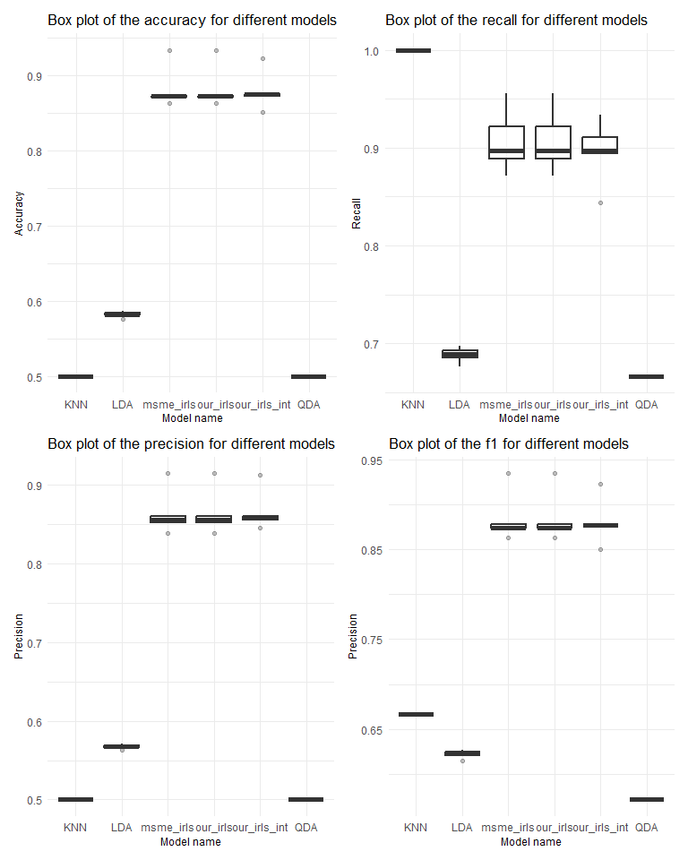

```r
multiple_eval <- multiple_exp(include_occupancy = TRUE)
boxplots(multiple_eval$out_raisin)
```

### Occupancy

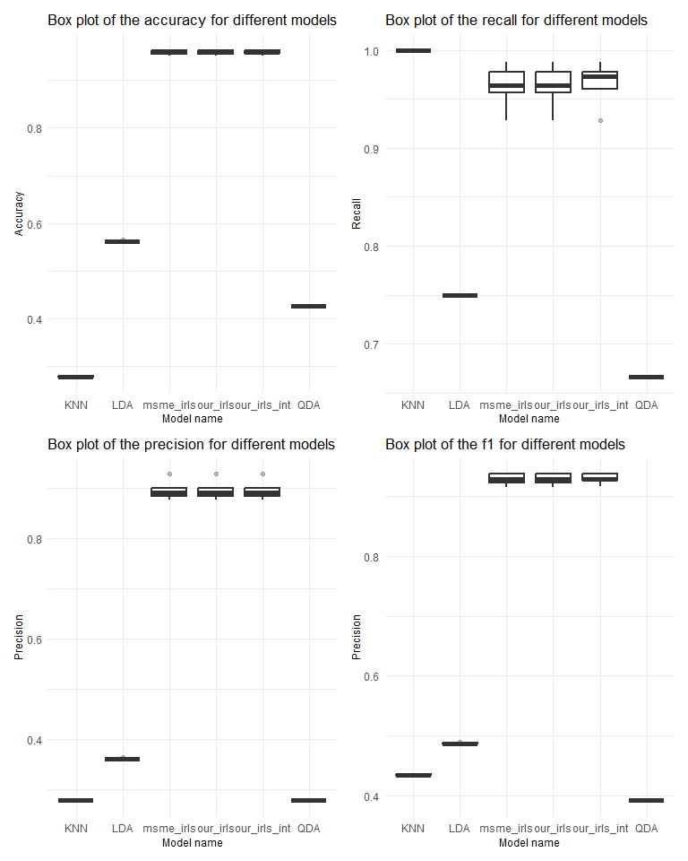

```r
boxplots(multiple_eval$out_occupancy)
```

### Banknote

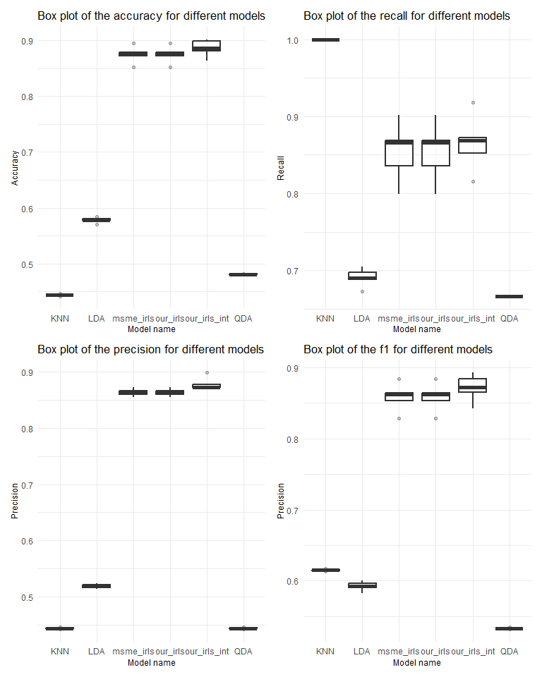

```r
boxplots(multiple_eval$out_banknote)
```